# Deep Learning — Assignment 1 — Score sheet

First assignment for the 2024 Deep Learning course (NWI-IMC070) of the Radboud University.

Please enter your names and group number.**Names:**

**Group:**

**Instructions:**

- Fill in your names and the name of your group.
- Answer the questions and complete the code where necessary.
- Keep your answers brief, one or two sentences is usually enough.
- Re-run the whole notebook before you submit your work.
- Save the notebook as a PDF and submit that in Brightspace together with the `.ipynb` notebook file.
- The easiest way to make a PDF of your notebook is via File > Print Preview and then use your browser's print option to print to PDF.

## Objectives

In this assignment you will

1. Experiment with gradient descent optimization;
2. Derive and implement gradients for binary cross-entropy loss, the logistic sigmoid function and a linear layer;
3. Test your gradient implementations with the finite difference method;
4. Use these components to implement and train a simple neural network.

```python
%matplotlib inline
import numpy as np
import scipy.optimize
import sklearn.datasets
import matplotlib.pyplot as plt
import torch

np.set_printoptions(suppress=True, precision=6, linewidth=200)
plt.style.use('ggplot')
```

## 1.1 Gradient descent optimization (6 points)

Consider the following function with two parameters and its partial derivatives: \begin{align} f(x, y) &= x^2 + y^2 + x (y + 2) + \cos(3x) \\ \frac{\partial f}{\partial x} &= 2x - 3\sin(3x) + y + 2 \\ \frac{\partial f}{\partial y} &= x + 2y \\ \end{align}

```python
def f(x, y):
    return x ** 2 + y ** 2 + x * (y + 2) + np.cos(3 * x)
def grad_x_f(x, y):
    return 2 * x - 3 * np.sin(3 * x) + y + 2
def grad_y_f(x, y):
    return x + 2 * y
```

A plot of the function shows that it has multiple local minima:

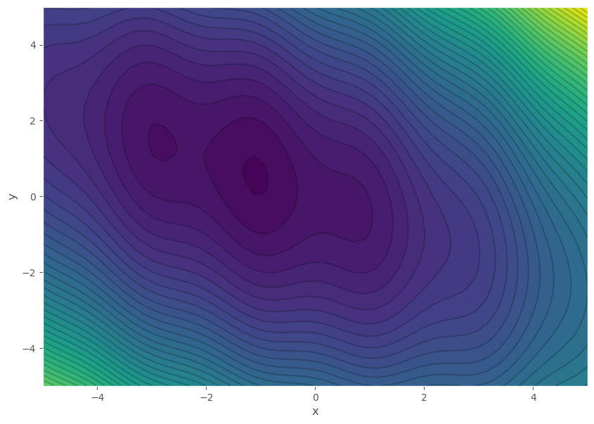

```python
def plot_f_contours():
    xx, yy = np.meshgrid(np.linspace(-5, 5), np.linspace(-5, 5))
    zz = f(xx, yy)
    plt.contourf(xx, yy, zz, 50)
    plt.contour(xx, yy, zz, 50, alpha=0.2, colors='black', linestyles='solid')
    plt.xlabel('x')
    plt.ylabel('y')

plt.figure(figsize=(10, 7))
plot_f_contours()
```

### Implement gradient descent

We would like to find the minimum of this function using gradient descent.

**1.1 a Add comment(a) Implement the gradient descent updates for $x$ and $y$ in the function below: (1 point)**

*Grading:*

- 1 point for a fully correct implementation.
- 0 points if the sign is incorrect (if you are doing gradient *ascent*)
- 0 points if not multiplying by `step_size`

```python
def optimize_f(x, y, step_size, steps):
    # keep track of the parameters we tried so far
    x_hist, y_hist = [x], [y]

    # run gradient descent for the number of steps
    for step in range(steps):
        # compute the gradients at the current point
        dx = grad_x_f(x, y)
        dy = grad_y_f(x, y)

        # apply the gradient descent updates to x and y
        ### BEGIN ANSWER
        x = x - step_size * dx
        y = y - step_size * dy
        ### END ANSWER

        # store the new parameters
        x_hist.append(x)
        y_hist.append(y)

    return x, y, f(x, y), x_hist, y_hist
```

```python
# The following assert statements check that your implementation behaves sensibly
# Use it to get a hint only if you are stuck.
assert optimize_f(3, 2, 0.1, 1)[0] != 3, "Hint: you are not changing `x`"
assert optimize_f(3, 2, 0.1, 1)[2] < f(3, 2), "Hint: the function value is increasing, you should be minimizing it, not maximizing."
assert abs(optimize_f(3, 2, 0.1, 1)[0] - 3) < 1, "Hint: you are probably taking steps that are too large."
```

### Tune the parameters

We will now try if our optimization method works.

Use this helper function to plot the results:

```python
# helper function that plots the results of the gradient descent optimization
def plot_gradient_descent_results(x, y, val, x_hist, y_hist):
    # plot the path on the contour plot
    plt.figure(figsize=(20, 7))
    plt.subplot(1, 2, 1)
    plot_f_contours()
    plt.plot(x_hist, y_hist, '.-')

    # plot the learning curve
    plt.subplot(1, 2, 2)
    plt.plot(f(np.array(x_hist), np.array(y_hist)), '.r-')
    plt.title('Minimum value: %f' % f(x_hist[-1], y_hist[-1]))
```

**(b) Run the gradient descent optimization with the following initial settings:**

`x=3, y=2, step_size=0.1, steps=10`

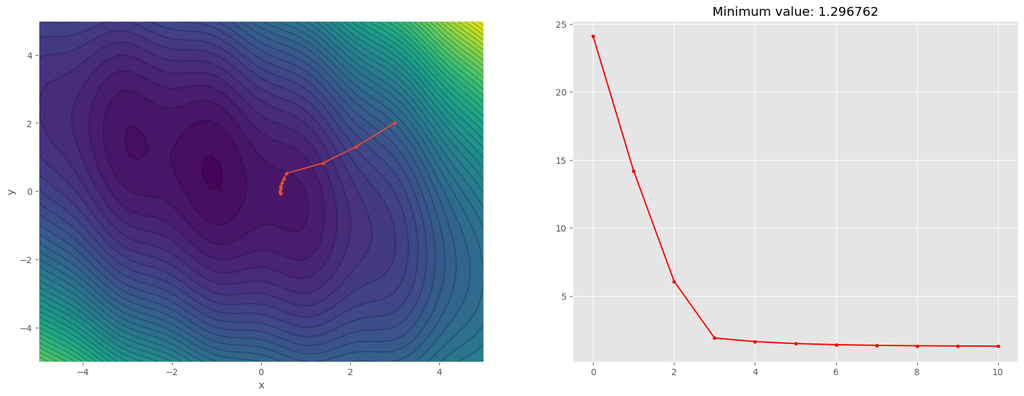

```python
results = optimize_f(x=3, y=2, step_size=0.1, steps=10)
plot_gradient_descent_results(*results)
```

**1.1 c Add comment(c) Does it find the minimum of the function? What happens? (1 point)**

Answer: No, the optimization ends in a local minimum, where it gets stuck.

*Grading:*

- 1 point for correctly observing that optimization ends in a local minimum.
- 0.5 point for answering "no" without mentioning that you end up in a local minimum or not in the global minimum.
- 0 points if you answer "yes".

**(d) Try a few different values for the `step_size` and the number of `steps` to get close to the optimal solution:**

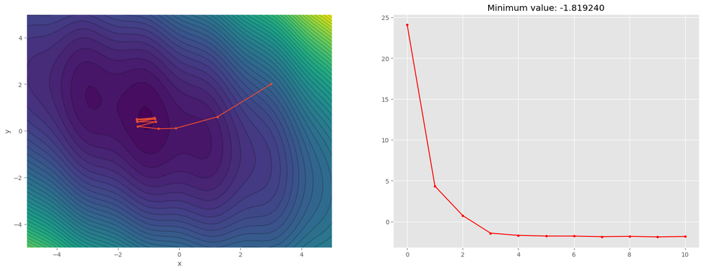

```python
### BEGIN ANSWER
results = optimize_f(x=3, y=2, step_size=0.2, steps=10)
### END ANSWER
plot_gradient_descent_results(*results)
assert results[2] < -1.5, "You should have a better result"
```

**1.1 e Add comment(e) What happens if you set the step size too small? And what if it is too large? (1 point)**

*Answer:*

The step size for this problem is quite sensitive. It should be large enough to escape the local optimum. With *too small* step sizes you get stuck there.

But if you set the step size it *too large* it will never converge. In that case the optimization moves around the global minimum, but never quite reaches it.

*Grading:*

- 0.5 point for "too small"
- 0.5 point for "too large"
- Max 0.5 points if there is no experiment performed

**1.1 f Add comment(f) Were you able to find a step size that reached the global optimum? If not, why not? (1 point)**

*Answer:*

Yes, or at least, you can get close.

With very careful tuning you might find a combination that gives a better result than we have here.

*Grading:*

- 1 point for a correct analysis that matches the result at 1(d).
- It is ok to argue that the optimum is never reached exactly, but that you can get close.

### Implement a decreasing step size

You might get better results if you use a step size that is large at the beginning, but slowly decreases during the optimization.

Try the following scheme to compute the step size $\eta_t$ in step $t$, given a decay parameter $d$: \begin{align} \eta_t = \eta_0 d^t \end{align}

**1.1 g Add comment(g) Update your optimization function to use this step size schedule: (1 point)**

*Grading:*

- 1 point for a fully correct implementation.
- You can either use `decay ** step` in the update steps, or multiply `step_size` by `decay` in every iteration.

```python
def optimize_f(x, y, step_size, steps, decay=1.0):
    # keep track of the parameters we tried so far
    x_hist, y_hist = [x], [y]

    # run gradient descent for the number of steps
    for step in range(steps):
        # compute the gradients at this point
        dx = grad_x_f(x, y)
        dy = grad_y_f(x, y)

        # apply the gradient descent updates to x and y
        ### BEGIN ANSWER
        x = x - dx * step_size * decay ** step
        y = y - dy * step_size * decay ** step
        ### END ANSWER

        # store the new parameters
        x_hist.append(x)
        y_hist.append(y)

    return x, y, f(x, y), x_hist, y_hist
```

```python
# The following assert statement checks that your implementation behaves sensibly
_trace = optimize_f(0.123, 0.456, 0.01, 2, 0.1)[3]
assert abs(_trace[1] - _trace[0]) > 5 * abs(_trace[2] - _trace[1]), "Hint: step size should be decreasing"
del _trace
```

**1.1 h Add comment(h) Tune the `step_sizes`, `steps` and `decay` parameters to get closer to the global minimum: (1 point)**

*Grading:*

- 1 point if you get reasonably close to the global minimum.
- The values below give one possible solution. The answer should have `decay < 1` and initial `step_size > 0.1`.

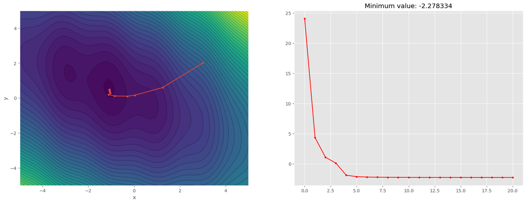

```python
### BEGIN ANSWER
results = optimize_f(x=3, y=2, step_size=0.2, steps=20, decay=0.9)
plot_gradient_descent_results(*results)
### END ANSWER
```

```python
assert results[2] < -2, "Hint: get closer to the optimum"
```

We will now look at some more complex functions that we can try to optimize.

## 1.2 Computing gradients with PyTorch (0 points)

It is inconvenient to define compute derivatives and gradients by hand. Fortunately, the [PyTorch](https://pytorch.org/) framework can do this for us.

PyTorch works very similarly to Numpy, but it has its own type of multi dimensional arrays, called `torch.Tensor`.

### Computing the gradients of a simple model

You can use the PyTorch tensors to perform computations, such as the function $y = x \cdot w + b$:

```python
w = torch.tensor(2.)
b = torch.tensor(1.)
x = torch.tensor(5.)
print('w:', w)
print('b:', b)
print('x:', x)

y = x * w + b
print("y:", y)
```

```
w: tensor(2.)
b: tensor(1.)
x: tensor(5.)
y: tensor(11.)
```

If we would like to compute the gradient for the parameters `w` and `b`, we could derive and compute them manually:

```python
grad_y_y = torch.tensor(1.)
grad_w_y = grad_y_y * x
grad_b_y = grad_y_y
print('grad_w_y:', grad_w_y)
print('grad_b_y:', grad_b_y)
```

```
grad_w_y: tensor(5.)
grad_b_y: tensor(1.)
```

### Computing the gradient automatically

You can compute an automatic gradient as follows:

1. Tell PyTorch which variables need a gradient. You can do this by setting `requires_grad=True` when you define the variable.
2. Perform a computation.
3. Call the `backward()` function on the result to compute the gradients.
4. The `.grad` field of your variables will now contain the gradient.

Have a look at this example, and compare the gradients with the gradients we computed manually:

```python
w = torch.tensor(2., requires_grad=True)
b = torch.tensor(1., requires_grad=True)
x = torch.tensor(5.)

# compute the function
y = x * w + b

# compute the gradients dy_dθ for all variables θ
y.backward()

print('w.grad:', w.grad)
print('b.grad:', b.grad)
# x did not have requires_grad, so no gradient was computed
print('x.grad:', x.grad)
```

```
w.grad: tensor(5.)
b.grad: tensor(1.)
x.grad: None
```

This also works for much more complicated functions, and even entire neural networks as you will see later:

```python
w = torch.tensor(2., requires_grad=True)
b = torch.tensor(1., requires_grad=True)
x = torch.tensor(5.)

y = torch.exp(torch.sin(x * w) + b)
y.backward()

print('w.grad:', w.grad)
print('b.grad:', b.grad)
```

```
w.grad: tensor(-6.6191)
b.grad: tensor(1.5777)
```

Note that `backward()` *adds* to `.grad`. So if you call it twice you get double the gradient. If you do not want this you need to reset the gradients yourself. We will see this later.

```python
w = torch.tensor(2., requires_grad=True)
b = torch.tensor(1., requires_grad=True)
x = torch.tensor(5.)

y = torch.exp(torch.sin(x * w) + b)
y.backward()

print('w.grad:', w.grad)
print('b.grad:', b.grad)

# Again
y = torch.exp(torch.sin(x * w) + b)
y.backward()

print()
print('w.grad:', w.grad)
print('b.grad:', b.grad)

# Again
w.grad = b.grad = None
y = torch.exp(torch.sin(x * w) + b)
y.backward()

print()
print('w.grad:', w.grad)
print('b.grad:', b.grad)
```

```
w.grad: tensor(-6.6191)
b.grad: tensor(1.5777)

w.grad: tensor(-13.2382)
b.grad: tensor(3.1554)

w.grad: tensor(-6.6191)
b.grad: tensor(1.5777)
```

### A note on working with vectors, matrices, and tensors

In Pytorch all operations work pointwise, so for example:

```python
torch.tensor([1,2]) * torch.tensor([3,4])
```

```
tensor([3, 8])
```

This is a pointwise product, not a vector dot product or a matrix product.

To compute a inner product (vector/matrix, matrix/matrix, or vector/vector dot product), use the `@` operator:

```python
print(torch.tensor([1,2]) @ torch.tensor([3,4]))
print(torch.tensor([1,2]) @ torch.tensor([[3,4,5],[6,7,8]]))
```

```
tensor(11)
tensor([15, 18, 21])
```

Sometimes you want to combine two tensors with different shapes, usually when one has a lower rank. Say you want to add 1 to all elements of a tensor, you can just write:

```python
torch.tensor([1,2]) + 1
```

```
tensor([2, 3])
```

But this only works if the last dimensions in the shape are the same.

```python
a = torch.tensor([[1,2,3],[4,5,6]])
b = torch.tensor([1,10])
print(a.shape)
print(b.shape)
#print(a + b) # This fails
```

```
torch.Size([2, 3])
torch.Size([2])
```

We can make it clear that we want to copy `b` along the second dimension by writing `b[:,None]`. The `:` means to keep that dimension as is, `None` means to copy along this new dimension.

```python
print(b[:,None].shape)
print(a + b[:,None])
print(b[None,:].shape)
print(a.transpose(0,1) + b[None,:])
```

```
torch.Size([2, 1])
tensor([[ 2,  3,  4],
        [14, 15, 16]])
torch.Size([1, 2])
tensor([[ 2, 14],
        [ 3, 15],
        [ 4, 16]])
```

## 1.3 Neural network components (6 points)

In this part of the assignment, we will implement a simple neural network from scratch. We need four components:

1. A logistic sigmoid activation function,
2. A ReLU activation function,
3. A binary cross-entropy loss function,
4. A multi-layer neural network

For each of these components we will have to implement the function. You can use the book or the slides as a reference.

### Logistic-sigmoid activation function

The logistic-sigmoid function is defined as:

\begin{align} \sigma(x) &= \frac{1}{1 + e^{-x}} \\ \end{align}

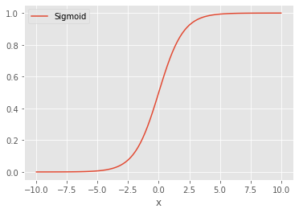

**1.3 a Add comment(a) Implement the logistic sigmoid in the function `sigmoid(x)`: (1 point)**

*Grading:*

- 1 point for a correctly implemented function.

```python
def sigmoid(x):
    ### BEGIN ANSWER
    return 1 / (1 + torch.exp(-x))
    ### END ANSWER

# try with some random inputs
torch.manual_seed(12345)
x = 10 * (torch.rand(5) - 0.5)
print('x:', x)
print('sigmoid(x):', sigmoid(x))

# Try with some extreme inputs
assert sigmoid(torch.tensor(0)) == 0.5
assert sigmoid(torch.tensor(-100)) == 0
assert sigmoid(torch.tensor(100)) == 1
```

```
x: tensor([ 4.8172,  3.7961,  4.9214, -0.3893, -4.1678])
sigmoid(x): tensor([0.9920, 0.9780, 0.9928, 0.4039, 0.0152])
```

### Rectified linear units (ReLU)

The rectified linear unit is defined as: \begin{align} f(x) = \max(0, x) \end{align}

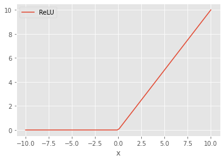

**1.3 b Add comment(b) Implement the ReLU function in the functions `relu(x)`: (1 points)**

*Grading:*

- 1 point for a correctly implemented function

```python
def relu(x):
    ### BEGIN ANSWER
    return torch.max(torch.tensor(0), x)
    ### END ANSWER

# try with some random inputs
torch.manual_seed(12345)
x = 10 * (torch.rand(5) - 0.5)
print('x:', x)
print('relu(x):', relu(x))

# Check properties
assert all(relu(x) >= 0)
assert relu(x).shape == x.shape
assert relu(torch.tensor(0)) == 0
assert relu(torch.tensor(-5)) == 0
assert relu(torch.tensor(5)) == 5
```

```
x: tensor([ 4.8172,  3.7961,  4.9214, -0.3893, -4.1678])
relu(x): tensor([4.8172, 3.7961, 4.9214, 0.0000, 0.0000])
```

### Comparing sigmoid and ReLU

The sigmoid and ReLU activation functions have slightly different characteristics.

**(c) Run the code below to plot the sigmoid and ReLU activation functions:**

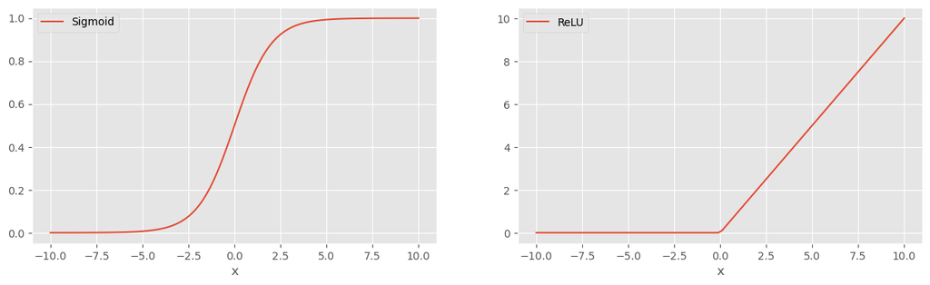

```python
x = torch.linspace(-10, 10, 100)

plt.figure(figsize=(15, 4))

plt.subplot(1, 2, 1)
plt.plot(x, sigmoid(x), label='Sigmoid')
plt.xlabel('x')
plt.legend(loc='upper left')

plt.subplot(1, 2, 2)
plt.plot(x, relu(x), label='ReLU')
plt.xlabel('x')
plt.legend(loc='upper left');
```

**1.3 d Add comment(d) Which activation function would you recommend for a network that outputs probabilities, i.e., outputs $\in [0, 1]$? Why? (1 point)**

*Answer:*

A sigmoid function, because its output is always between 0 and 1. A ReLU can give outputs outside this range.

*Grading:*

- 1 point for a correct answer and argumentation.
- 0.5 point if missing argumentation.

### Binary cross-entropy loss

We will use the binary cross-entropy loss to train our network. This loss function is useful for binary classification.

The binary cross-entropy (BCE) is a function of the ground truth label $y \in \{0, 1\}$ and the predicted label $\hat{y} \in [0, 1]$:

\begin{align} \ell(y, \hat{y}) &= -(y \log{\hat{y}} + (1-y) \log(1-\hat{y})) \\ \end{align}

The BCE loss is the average of the loss function for all samples in a dataset,

\begin{align} L = \frac{1}{N} \sum_{i=1}^N \ell(y_i, \hat{y}_i) \end{align}

Note: pytorch has a built in function for computing the mean.

**1.3 e Add comment(e) Implement `bce_loss(y, y_hat)`: (1 point)**

*Grading:*

- 1 point for a correctly implemented function

```python
def bce_loss(y, y_hat):
    ### BEGIN ANSWER
    return -torch.mean((y * torch.log(y_hat) + (1 - y) * torch.log(1 - y_hat)))
    ### END ANSWER

# try with some random inputs
torch.manual_seed(12345)
y = torch.randint(2, size=(5,))
y_hat = torch.rand(size=(5,))
print('y:', y)
print('y_hat:', y_hat)
print('bce_loss(y, y_hat):', bce_loss(y, y_hat))
print()

# Properties
assert tuple(bce_loss(torch.tensor([1]), torch.tensor([0.123])).shape) == (), "The loss should be a scalar"
assert bce_loss(torch.tensor([1]), torch.tensor([0.123])) == bce_loss(torch.tensor([0]), torch.tensor([1-0.123])), "Flipping the label and prediction should give the same loss"
assert bce_loss(torch.tensor([1,1]), torch.tensor([0.123,0.123])) == bce_loss(torch.tensor([1,1]), torch.tensor([0.123,0.123])), "The loss should be the mean over all samples"
```

```
y: tensor([0, 1, 1, 1, 0])
y_hat: tensor([0.1784, 0.3674, 0.5676, 0.3376, 0.2119])
bce_loss(y, y_hat): tensor(0.6176)
```

**1.3 f Add comment(f) Compute the BCE loss for a perfect prediction. Is this the correct answer? (1 point)**

```python
### BEGIN ANSWER
bce_loss(torch.tensor([1]), torch.tensor([1]))
### END ANSWER
```

```
tensor(nan)
```

*Answer:* The loss should be 0 if the prediction matches the true label. But the computation involves $0*\log(0)$, which is $0*\infty$, which is undefined. We want to return 0 instead.

*Grading:*

- 0.5 points for getting a nan in the computation.
- 0.5 points for the explanation.
- full points if the bce_loss function was already implemented in a way that avoids the problem.

The proper way to implement cross-entropy is to combine it with the logistic sigmoid activation function. But for now we can use one of two simple ways to fix this issue:

- Ensure that the predicted probabilities are never exactly 0 or 1. For example by scaling them to the range `[1e-6; 1-1e-6]`.
- Or use [`torch.where`](https://pytorch.org/docs/stable/generated/torch.where.html) or indexing with `tensor[y==1]`, to implement the loss function as \begin{align} \ell(y, \hat{y}) &= \begin{cases} -\log{\hat{y}} &\text{if } y=1\\ -\log(1-\hat{y}) & \text{if } y=0\end{cases} \end{align} However, due to how torch.where is implemented it can still give problems later on.

**1.3 g Add comment(g) Give an implementation of BCE loss with this issue fixed (1 point)**

*Grading:*

- 1 point for scaling, clamping or selecting. The implementation should pass the tests.
- It is ok if the scaling or clamping is slightly different from the `1e-6` used here.

```python
def bce_loss(y, y_hat):
    ### BEGIN ANSWER
    # Ensure predicted probabilities are not 0 or 1 by rescaling
    y_hat = y_hat * (1 - 1e-6) + 0.5e-6
    return -torch.mean((y * torch.log(y_hat) + (1 - y) * torch.log(1 - y_hat)))
    # Or by clamping
    y_hat = torch.clamp(y_hat, 1e-6, 1-1e-6)
    return -torch.mean((y * torch.log(y_hat) + (1 - y) * torch.log(1 - y_hat)))
    # Alternative solution: Select only one of the logarithms
    # This can still give problematic gradients
    return -torch.mean(torch.where(y == 1, torch.log(y_hat), torch.log1p(-y_hat)))
    ### END ANSWER

# Test bce_loss for perfect predictions
assert bce_loss(torch.tensor([0]), torch.tensor([0])) < 2e-6
assert bce_loss(torch.tensor([1]), torch.tensor([1])) < 2e-6
assert bce_loss(torch.tensor([0]), torch.tensor([1])) > 10
assert bce_loss(torch.tensor([1]), torch.tensor([0])) > 10
# Checks from before should still hold
assert tuple(bce_loss(torch.tensor([1]), torch.tensor([0.123])).shape) == (), "The loss should be a scalar"
assert abs(bce_loss(torch.tensor([1]), torch.tensor([0.123])) - bce_loss(torch.tensor([0]), torch.tensor([1-0.123]))) < 1e-6, "Flipping the label and prediction should give the same loss"
assert bce_loss(torch.tensor([1,1]), torch.tensor([0.123,0.123])) == bce_loss(torch.tensor([1,1]), torch.tensor([0.123,0.123])), "The loss should be the mean over all samples"
```

## 1.4 Implement a one-layer model (2 points)

We will first implement a simple one-layer model with a sigmoid activation:

Given an input vector $\mathbf{x}$, weight vector $\mathbf{w}$ and bias $b$, compute the output $\hat{y}$:

\begin{align} \tilde{y} = \mathbf{x} \cdot \mathbf{w} + b \\ \hat{y} = \sigma(\tilde{y}) \\ \end{align}

Hint: in torch inner product and matrix multiplication is denoted as `A @ B`.

**1.4 a Add comment(a) Complete the implementation below: (2 points)**

*Grading:*

- 1 point for computing the pre-activations `y_tilde`
- 1 point for the activations `y_hat`
- For computing `h`, `np.dot` or `@` is required, `x * w` gives a pointwise multiplication which is incorrect.

```python
# initialize parameters
torch.manual_seed(12345)
w = torch.randn(size=(5,))
b = torch.randn(size=[])

# implement the model
def model1(x):
    ### BEGIN ANSWER
    # compute y_tilde, y_hat
    y_tilde = x @ w + b
    y_hat = sigmoid(y_tilde)
    ### END ANSWER
    return y_hat

# test with a random input
x = torch.randn(size=(5,))

y_hat = model1(x)
print("y_hat:", y_hat)

assert tuple(y_hat.shape) == (), "There should be one output"
```

```
y_hat: tensor(0.0841)
```

## 1.5 Implement a multi-layer network (5 points)

We are now ready to implement a more general neural network function. This will follow the "network in one line" from the slides, or eq (6.19) from Bishop.

The `network` function takes an input `x`, and a list of parameters. For each layer the parameters contain weights `w`, biasses `b`, and an activation function `h`.

For each layer, we should compute a linear transformation of the previous layer's output `z`, and then apply the activation function.

The function should work on multiple samples at the same time, so `x` and `z` should be rank 2 tensors.

**1.5 a Add comment(a) Complete the implementation below: (2 points)**

*Grading:*

- 1 point for the linear transformation
- 1 point for applying `h`

```python
def network(x, params):
    z = x
    for l, (w, b, h) in enumerate(params):
        # Compute z^(l) given z^(l-1)
        ### BEGIN ANSWER
        z = h(z @ w + b)
        ### END ANSWER
    # Final output. Note: squeeze removes the last dimension if there is only 1 output
    y = z.squeeze(dim=-1)
    return y

# Test with a simple networks. N=2, D₀=5, D₁=10, D₂=1
torch.manual_seed(12345)
params = [(torch.randn((5,10)), torch.zeros((10,)), relu)
         ,(torch.randn((10,1)), torch.zeros((1,)), sigmoid)]
x = torch.randn((2,5))
y = network(x, params)
print(y)
assert tuple(y.shape) == (2,), "Expected two samples and one output channel"
```

```
tensor([0.7187, 0.1632])
```

For initializing the parameters and describing the network architecture, we can make a helper function. This function should initialize the parameters for a single layer.

- You should initialize the weights using He initialization. That is: drawn from a normal distribution with the variance as described in the slides.
- You should initialize the biases to zero

**1.5 b Add comment(b) Complete the implementation below: (3 points)**

*Grading:*

- 1 point for `epsilon`
  - it is ok to use `sqrt(2 / d1)`, this is incorrect, but was the solution accepted by a previous version of the assignment.
- 1 point for `w`
  - weights should be random normal, and scaled by `epsilon`
- 1 point for `b`
  - biases should be 0

```python
def make_layer(d0, d1, activation):
    """
    Create the parameters for a layer in the neural network, with input size d0, and output size d1.
    Weights are initialized with He initialization.
    Biases are initialized to 0.
    """
    ### BEGIN ANSWER
    # Choose initialization scale. Use He initialization
    epsilon = np.sqrt(2 / d0)
    # Initialize weights randomly
    w = epsilon * torch.randn((d0,d1))
    # Initialize biases to zero
    b = torch.zeros((d1,))
    ### END ANSWER
    return (w.double(), b.double(), activation)

# Tests
assert len(make_layer(5, 10, sigmoid)) == 3
assert tuple(make_layer(5, 10, sigmoid)[0].shape) == (5,10), "Weight has the wrong shape"
assert tuple(make_layer(5, 10, sigmoid)[1].shape) == (10,), "Bias has the wrong shape"
assert abs(torch.mean(make_layer(2, 100000, sigmoid)[0]) - 0) < 1e-2, "Weights should have mean 0"
assert abs(torch.std(make_layer(2, 100000, sigmoid)[0]) - 1) < 1e-2, "Scale of the weights is wrong"
assert abs(torch.std(make_layer(8, 100000, sigmoid)[0]) - 0.5) < 1e-2, "Scale of the weights is wrong"
assert all(make_layer(1, 100, sigmoid)[1] == 0), "Biases should be zero"
```

## 1.6 Training the network (17 points)

Each sample has $8 \times 8$ pixels, arranged as a 1D vector of 64 features.

```
digits_x.shape: torch.Size([1797, 64])
digits_y.shape: torch.Size([1797])
min, max values: -0.8117526680606131 1.8474621222310277
labels: tensor([0., 1.], dtype=torch.float64)
```

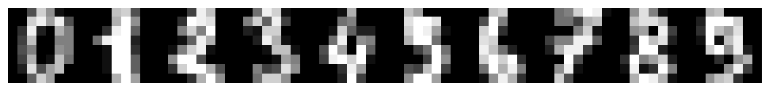

```python
# load the first two classes of the digits dataset
dataset = sklearn.datasets.load_digits()

# create a binary classification problem
digits_x = torch.tensor(dataset['data']).double()
digits_y = torch.tensor(dataset['target'] < 5).double()

# plot some of the digits
plt.figure(figsize=(10, 2))
plt.imshow(np.hstack([digits_x[i].reshape(8, 8) for i in range(10)]), cmap='gray')
plt.grid(False)
plt.tight_layout()
plt.axis('off')

# normalize the values to mean 0, standard deviation 1
digits_x -= torch.mean(digits_x)
digits_x /= torch.std(digits_x)

# print some statistics
print('digits_x.shape:', digits_x.shape)
print('digits_y.shape:', digits_y.shape)
print('min, max values:', torch.min(digits_x).item(), torch.max(digits_x).item())
print('labels:', torch.unique(digits_y))
```

We divide the dataset in a train and a validation set.

```python
# make a 50%/50% train/validation split
train_prop = 0.5
n_train = int(digits_x.shape[0] * train_prop)

# shuffle the datapoints
torch.manual_seed(12345)
idxs = torch.randperm(digits_x.shape[0])

# take a subset
split_x = {'train': digits_x[idxs[:n_train]],
           'val':   digits_x[idxs[n_train:]]}
split_y = {'train': digits_y[idxs[:n_train]],
           'val':   digits_y[idxs[n_train:]]}

print('Training samples:', split_x['train'].shape[0])
print('Validation samples:', split_x['val'].shape[0])
```

```
Training samples: 898
Validation samples: 899
```

We will now implement a function that trains the network. We will first define some helper functions for working with gradients:

```python
def enable_gradients(params):
    """
    Enable gradient computation for the model parameters.
    """
    for w, b, h in params:
        w.requires_grad_()
        b.requires_grad_()

def add_gradients(params, step):
    """
    Update the parameters: θ ← θ + step * ∇_θ
    """
    with torch.no_grad():
        for w, b, h in params:
            if any(w.grad.flatten().isnan()) or any(b.grad.flatten().isnan()):
                raise Exception("Gradients are nan, something went wrong")
            w += step * w.grad
            b += step * b.grad

def clear_gradients(params):
    """
    Reset the computed gradients.
    """
    for w, b, h in params:
        w.grad = None
        b.grad = None
```

Next we will implement a function that evaluates the performance on the validation set:

**1.6 a Add comment(a) Complete the code below: (2 points)**

*Grading:*

- 1 point for y_hat
- 0.5 points for loss, 0.5 points for acc

```python
def accuracy(y, y_hat):
    """Compute accuracy"""
    return torch.mean(((y > 0.5) == (y_hat > 0.5)).float())

def evaluate(params, x, y):
    """
    Evaluate the performance of the network.
    Returns: loss and accuracy.
    """
    with torch.no_grad(): # tells torch we don't need gradients
        ### BEGIN ANSWER
        y_hat = network(x, params)
        loss  = bce_loss(y, y_hat)
        acc   = accuracy(y, y_hat)
        ### END ANSWER
        return loss.item(), acc.item()
```

**(b) Run the code below to compute the loss and accuracy of an untrained network: (no points)**

```python
# Initialize parameters
params = [
    make_layer(64, 32, relu),
    make_layer(32, 1, sigmoid),
]
evaluate(params, split_x['val'], split_y['val'])
```

```
(0.7238883994250982, 0.5895439386367798)
```

Now we can define a training loop.

For each epoch, the function `fit` loops over all minibatches in the training set and updates the network parameters. It will then compute the loss and accuracy for the validation samples. Finally, it will plot the learning curves.

The actual training happens in `train_epoch`. There is still some work to be done there.

**1.6 c Add comment(c) Complete the code below: (5 points)**

*Grading:*

- 1 point for calling `clear_gradients`
- 1 point for computing the network output
- 1 point for computing loss and accuracy
- 1 point for calling `backward`
- 1 point for calling `add_gradients` with step size `-learning_rate`
  - no points when using the wrong learning rate, or the wrong sign in `add_gradients`
  - no points when `add_gradients` is modified instead.
  - no points if loss is changed instead, for example to `-loss`.

```python
def train_epoch(params, x_train, y_train, learning_rate, batch_size):
    """
    One epoch of training with gradient descent
    """
    n = len(x_train)
    if batch_size is None or batch_size > n:
        batch_size = n
    num_batches = n // batch_size
    # randomize the order in which we see the samples
    random_order = torch.randperm(n)
    # keep tarck of the loss and accuracy
    loss_total = 0
    accuracy_total = 0

    for step in range(num_batches):
        # Get a minibatch
        x_batch = x_train[random_order[step*batch_size : (step+1)*batch_size]]
        y_batch = y_train[random_order[step*batch_size : (step+1)*batch_size]]

        # Compute loss and update parameters
        ### BEGIN ANSWER
        clear_gradients(params)
        y_hat = network(x_batch, params)
        loss = bce_loss(y_batch, y_hat)
        acc  = accuracy(y_batch, y_hat)
        loss.backward()
        add_gradients(params, -learning_rate)
        ### END ANSWER

        loss_total += loss.item()
        accuracy_total += acc.item()

    return loss_total / num_batches, accuracy_total / num_batches


def fit(params, x, y, epochs=25, **kwargs):
    """
    Optimize the the parameters with gradient descent
    """
    # Initialize the loss and accuracy history
    loss_hist = {'train': [], 'val': []}
    accuracy_hist = {'train': [], 'val': []}

    # Enable gradients for the parameters
    enable_gradients(params)

    for epoch in range(epochs):
        # Training
        train_loss, train_acc = train_epoch(params, x['train'], y['train'], **kwargs)
        loss_hist['train'].append(train_loss)
        accuracy_hist['train'].append(train_acc)

        # Validation
        test_loss, test_acc = evaluate(params, x['val'], y['val'])
        loss_hist['val'].append(test_loss)
        accuracy_hist['val'].append(test_acc)

        print(f'Epoch {epoch:3}: train loss {train_loss:.3f}, acc {train_acc:.3f};  validation loss {test_loss:.3f}, acc {test_acc:.3f}')

    # Print final results
    print(f'After {epochs} epochs')
    print(f'  train      loss {train_loss:.3f}, accuracy {train_acc:.3f}')
    print(f'  validation loss {test_loss:.3f}, accuracy {test_acc:.3f}')

    # Plot the learning curves
    fig = plt.figure(figsize=(20, 5))

    plt.subplot(1, 2, 1)
    for phase in loss_hist:
        plt.plot(loss_hist[phase], label=phase)
    plt.title('BCE loss')
    plt.xlabel('Epoch')
    plt.legend()

    plt.subplot(1, 2, 2)
    for phase in accuracy_hist:
        plt.plot(accuracy_hist[phase], label=phase)
    plt.title('Accuracy')
    plt.xlabel('Epoch')
    plt.legend()
```

We will define a two-layer network:

- A layer that maps the 64 features of the input to 32 features.
- A ReLU activation function.
- A layer that maps the 32 features to the 1 output features.
- A sigmoid activation function that maps the output to [0, 1].

**1.6 d Add comment(d) Train the network and inspect the results. Tune the hyperparameters to get a good result. (1 point)**

(Hint: it is possible to get validation accuracy >= 0.95)

*Grading:*

```
Epoch   0: train loss 0.610, acc 0.671;  validation loss 0.555, acc 0.741
Epoch   1: train loss 0.498, acc 0.802;  validation loss 0.470, acc 0.818
Epoch   2: train loss 0.422, acc 0.855;  validation loss 0.406, acc 0.842
Epoch   3: train loss 0.365, acc 0.878;  validation loss 0.366, acc 0.860
Epoch   4: train loss 0.330, acc 0.889;  validation loss 0.343, acc 0.869
Epoch   5: train loss 0.303, acc 0.898;  validation loss 0.318, acc 0.877
Epoch   6: train loss 0.283, acc 0.902;  validation loss 0.301, acc 0.881
Epoch   7: train loss 0.262, acc 0.912;  validation loss 0.287, acc 0.879
Epoch   8: train loss 0.246, acc 0.919;  validation loss 0.275, acc 0.893
Epoch   9: train loss 0.235, acc 0.924;  validation loss 0.265, acc 0.895
Epoch  10: train loss 0.222, acc 0.926;  validation loss 0.255, acc 0.898
Epoch  11: train loss 0.213, acc 0.930;  validation loss 0.250, acc 0.900
Epoch  12: train loss 0.204, acc 0.937;  validation loss 0.243, acc 0.903
Epoch  13: train loss 0.196, acc 0.935;  validation loss 0.234, acc 0.907
Epoch  14: train loss 0.185, acc 0.936;  validation loss 0.229, acc 0.905
Epoch  15: train loss 0.180, acc 0.936;  validation loss 0.222, acc 0.911
Epoch  16: train loss 0.174, acc 0.940;  validation loss 0.216, acc 0.915
Epoch  17: train loss 0.169, acc 0.940;  validation loss 0.212, acc 0.919
Epoch  18: train loss 0.163, acc 0.945;  validation loss 0.207, acc 0.920
Epoch  19: train loss 0.157, acc 0.948;  validation loss 0.204, acc 0.919
Epoch  20: train loss 0.153, acc 0.949;  validation loss 0.198, acc 0.923
Epoch  21: train loss 0.149, acc 0.955;  validation loss 0.193, acc 0.923
Epoch  22: train loss 0.143, acc 0.953;  validation loss 0.190, acc 0.925
Epoch  23: train loss 0.139, acc 0.956;  validation loss 0.186, acc 0.928
Epoch  24: train loss 0.134, acc 0.960;  validation loss 0.185, acc 0.925
After 25 epochs
  train      loss 0.134, accuracy 0.960
  validation loss 0.185, accuracy 0.925
```

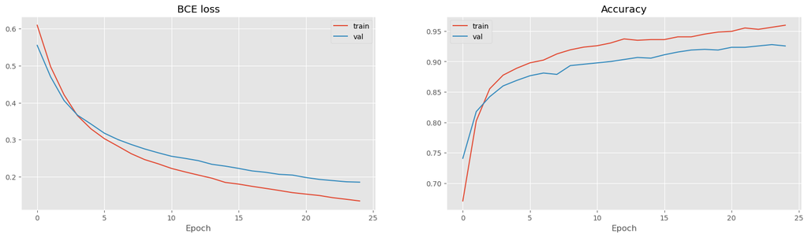

```python
# Initialize parameters
params = [
    make_layer(64, 32, relu),
    make_layer(32, 1, sigmoid),
]

### BEGIN ANSWER
fit(params, split_x, split_y,
    epochs = 25,
    learning_rate = 0.01,
    batch_size = 10
   )
### END ANSWER
```

**1.6 e Add comment(e) How did each of the hyperparameters (number of epochs, learning rate, minibatch size) influence your results? How important is it to set each correctly? (3 points)**

Answer

- It is important to set the number of epochs large enough. The model takes some time to reach a good performance.
- The learning rate must not be too small, which would slow down training, but also not too large, because that causes instabilities.
- The minibatch size is less important, as long as it is large enough.

*Grading:*

- 1 point for each of the three hyperparameters.

**1.6 f Add comment(f) Create and train a network with a single layer with sigmoid activation: (1 point)**

*Grading:*

- 1 point for a correct implementation, trained with good hyperparameters.

```
Epoch   0: train loss 0.791, acc 0.470;  validation loss 0.681, acc 0.588
Epoch   1: train loss 0.608, acc 0.657;  validation loss 0.567, acc 0.753
Epoch   2: train loss 0.517, acc 0.771;  validation loss 0.502, acc 0.809
Epoch   3: train loss 0.466, acc 0.810;  validation loss 0.462, acc 0.829
Epoch   4: train loss 0.430, acc 0.824;  validation loss 0.436, acc 0.832
Epoch   5: train loss 0.405, acc 0.849;  validation loss 0.415, acc 0.845
Epoch   6: train loss 0.390, acc 0.849;  validation loss 0.400, acc 0.849
Epoch   7: train loss 0.374, acc 0.858;  validation loss 0.388, acc 0.857
Epoch   8: train loss 0.360, acc 0.867;  validation loss 0.380, acc 0.854
Epoch   9: train loss 0.352, acc 0.872;  validation loss 0.371, acc 0.861
Epoch  10: train loss 0.344, acc 0.873;  validation loss 0.364, acc 0.863
Epoch  11: train loss 0.338, acc 0.878;  validation loss 0.359, acc 0.865
Epoch  12: train loss 0.333, acc 0.876;  validation loss 0.354, acc 0.867
Epoch  13: train loss 0.326, acc 0.880;  validation loss 0.350, acc 0.863
Epoch  14: train loss 0.318, acc 0.876;  validation loss 0.346, acc 0.871
Epoch  15: train loss 0.318, acc 0.878;  validation loss 0.342, acc 0.871
Epoch  16: train loss 0.314, acc 0.882;  validation loss 0.339, acc 0.872
Epoch  17: train loss 0.310, acc 0.882;  validation loss 0.337, acc 0.872
Epoch  18: train loss 0.306, acc 0.881;  validation loss 0.333, acc 0.874
Epoch  19: train loss 0.301, acc 0.890;  validation loss 0.332, acc 0.868
Epoch  20: train loss 0.299, acc 0.885;  validation loss 0.329, acc 0.877
Epoch  21: train loss 0.297, acc 0.887;  validation loss 0.327, acc 0.875
Epoch  22: train loss 0.295, acc 0.890;  validation loss 0.325, acc 0.875
Epoch  23: train loss 0.292, acc 0.888;  validation loss 0.323, acc 0.877
Epoch  24: train loss 0.293, acc 0.885;  validation loss 0.321, acc 0.877
Epoch  25: train loss 0.290, acc 0.887;  validation loss 0.320, acc 0.878
Epoch  26: train loss 0.289, acc 0.887;  validation loss 0.320, acc 0.877
Epoch  27: train loss 0.282, acc 0.897;  validation loss 0.317, acc 0.877
Epoch  28: train loss 0.282, acc 0.892;  validation loss 0.316, acc 0.878
Epoch  29: train loss 0.283, acc 0.891;  validation loss 0.315, acc 0.879
Epoch  30: train loss 0.280, acc 0.894;  validation loss 0.313, acc 0.880
Epoch  31: train loss 0.279, acc 0.893;  validation loss 0.313, acc 0.879
Epoch  32: train loss 0.278, acc 0.894;  validation loss 0.311, acc 0.881
Epoch  33: train loss 0.273, acc 0.894;  validation loss 0.311, acc 0.877
Epoch  34: train loss 0.275, acc 0.888;  validation loss 0.309, acc 0.881
Epoch  35: train loss 0.274, acc 0.890;  validation loss 0.308, acc 0.885
Epoch  36: train loss 0.270, acc 0.896;  validation loss 0.307, acc 0.882
Epoch  37: train loss 0.270, acc 0.892;  validation loss 0.307, acc 0.885
Epoch  38: train loss 0.271, acc 0.893;  validation loss 0.306, acc 0.885
Epoch  39: train loss 0.269, acc 0.892;  validation loss 0.305, acc 0.887
Epoch  40: train loss 0.269, acc 0.893;  validation loss 0.305, acc 0.887
Epoch  41: train loss 0.266, acc 0.899;  validation loss 0.304, acc 0.884
Epoch  42: train loss 0.265, acc 0.896;  validation loss 0.303, acc 0.884
Epoch  43: train loss 0.261, acc 0.897;  validation loss 0.303, acc 0.885
Epoch  44: train loss 0.262, acc 0.902;  validation loss 0.302, acc 0.883
Epoch  45: train loss 0.264, acc 0.897;  validation loss 0.301, acc 0.888
Epoch  46: train loss 0.262, acc 0.898;  validation loss 0.300, acc 0.887
Epoch  47: train loss 0.263, acc 0.902;  validation loss 0.300, acc 0.884
Epoch  48: train loss 0.263, acc 0.900;  validation loss 0.300, acc 0.888
Epoch  49: train loss 0.260, acc 0.901;  validation loss 0.300, acc 0.889
After 50 epochs
  train      loss 0.260, accuracy 0.901
  validation loss 0.300, accuracy 0.889
```

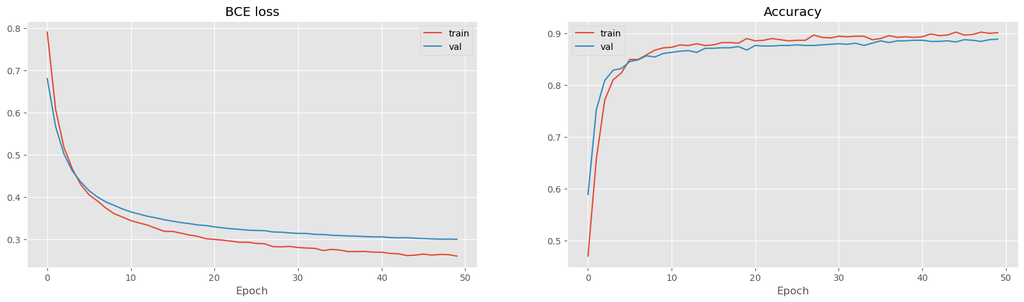

```python
### BEGIN ANSWER
params = [
    make_layer(64, 1, sigmoid),
]

# train the network
fit(params, split_x, split_y,
    epochs = 50,
    learning_rate = 0.01,
    batch_size = 10)
### END ANSWER
```

**1.6 g Add comment(g) Discuss your results. Compare the results of this single-layer network with those of the network you trained before. (1 point)**

Answer: The validation accuracy of the network with a single linear layer is lower than that of the previous, more complex network with two linear layers. The additional layer allows the model to make better predictions.

For the shallow network, the difference between the train and validation accuracy is smaller than for the deeper network. The deeper network is overfitting slightly to the training set, because it is more complex. (But the performance on the validation set is also improved, so the overfitting is not too harmful.)

*Grading:*

- 0.5 point for correctly comparing validation performance with more complex network.
- plus 0.5 point for also discussing training performance or discussing under-/overfitting.

**1.6 h Add comment(h) Repeat the experiment with a network with two linear layers, without an activation function in between, followed by a sigmoid activation. (1 point)**

You can make a layer without an activation function by using the identity function as the activation function: `lambda x: x`.

*Grading:*

- 1 point for a correct implementation, trained with good hyperparameters.

```
Epoch   0: train loss 0.727, acc 0.578;  validation loss 0.554, acc 0.750
Epoch   1: train loss 0.463, acc 0.792;  validation loss 0.457, acc 0.783
Epoch   2: train loss 0.392, acc 0.836;  validation loss 0.398, acc 0.841
Epoch   3: train loss 0.354, acc 0.866;  validation loss 0.371, acc 0.858
Epoch   4: train loss 0.329, acc 0.872;  validation loss 0.356, acc 0.862
Epoch   5: train loss 0.317, acc 0.875;  validation loss 0.341, acc 0.863
Epoch   6: train loss 0.300, acc 0.891;  validation loss 0.337, acc 0.875
Epoch   7: train loss 0.295, acc 0.880;  validation loss 0.329, acc 0.874
Epoch   8: train loss 0.283, acc 0.887;  validation loss 0.326, acc 0.878
Epoch   9: train loss 0.283, acc 0.885;  validation loss 0.316, acc 0.879
Epoch  10: train loss 0.278, acc 0.889;  validation loss 0.311, acc 0.885
Epoch  11: train loss 0.271, acc 0.894;  validation loss 0.318, acc 0.877
Epoch  12: train loss 0.267, acc 0.894;  validation loss 0.313, acc 0.875
Epoch  13: train loss 0.265, acc 0.903;  validation loss 0.310, acc 0.889
Epoch  14: train loss 0.264, acc 0.890;  validation loss 0.311, acc 0.873
Epoch  15: train loss 0.260, acc 0.899;  validation loss 0.300, acc 0.887
Epoch  16: train loss 0.257, acc 0.892;  validation loss 0.316, acc 0.882
Epoch  17: train loss 0.256, acc 0.893;  validation loss 0.310, acc 0.877
Epoch  18: train loss 0.257, acc 0.898;  validation loss 0.298, acc 0.889
Epoch  19: train loss 0.246, acc 0.902;  validation loss 0.297, acc 0.889
Epoch  20: train loss 0.252, acc 0.906;  validation loss 0.298, acc 0.890
Epoch  21: train loss 0.246, acc 0.907;  validation loss 0.298, acc 0.888
Epoch  22: train loss 0.250, acc 0.904;  validation loss 0.297, acc 0.885
Epoch  23: train loss 0.249, acc 0.903;  validation loss 0.295, acc 0.889
Epoch  24: train loss 0.243, acc 0.912;  validation loss 0.297, acc 0.890
Epoch  25: train loss 0.241, acc 0.906;  validation loss 0.305, acc 0.890
Epoch  26: train loss 0.246, acc 0.907;  validation loss 0.297, acc 0.889
Epoch  27: train loss 0.246, acc 0.896;  validation loss 0.296, acc 0.893
Epoch  28: train loss 0.244, acc 0.904;  validation loss 0.298, acc 0.890
Epoch  29: train loss 0.242, acc 0.908;  validation loss 0.304, acc 0.890
Epoch  30: train loss 0.244, acc 0.906;  validation loss 0.297, acc 0.891
Epoch  31: train loss 0.243, acc 0.904;  validation loss 0.296, acc 0.887
Epoch  32: train loss 0.241, acc 0.909;  validation loss 0.293, acc 0.892
Epoch  33: train loss 0.240, acc 0.907;  validation loss 0.293, acc 0.891
Epoch  34: train loss 0.243, acc 0.908;  validation loss 0.294, acc 0.890
Epoch  35: train loss 0.239, acc 0.908;  validation loss 0.295, acc 0.891
Epoch  36: train loss 0.242, acc 0.904;  validation loss 0.298, acc 0.889
Epoch  37: train loss 0.240, acc 0.910;  validation loss 0.302, acc 0.889
Epoch  38: train loss 0.239, acc 0.913;  validation loss 0.293, acc 0.890
Epoch  39: train loss 0.237, acc 0.911;  validation loss 0.298, acc 0.888
Epoch  40: train loss 0.238, acc 0.910;  validation loss 0.296, acc 0.890
Epoch  41: train loss 0.235, acc 0.910;  validation loss 0.299, acc 0.890
Epoch  42: train loss 0.237, acc 0.918;  validation loss 0.300, acc 0.890
Epoch  43: train loss 0.240, acc 0.909;  validation loss 0.296, acc 0.892
Epoch  44: train loss 0.239, acc 0.911;  validation loss 0.304, acc 0.889
Epoch  45: train loss 0.239, acc 0.912;  validation loss 0.299, acc 0.889
Epoch  46: train loss 0.239, acc 0.908;  validation loss 0.300, acc 0.889
Epoch  47: train loss 0.238, acc 0.907;  validation loss 0.298, acc 0.890
Epoch  48: train loss 0.238, acc 0.911;  validation loss 0.298, acc 0.890
Epoch  49: train loss 0.241, acc 0.910;  validation loss 0.296, acc 0.890
After 50 epochs
  train      loss 0.241, accuracy 0.910
  validation loss 0.296, accuracy 0.890
```

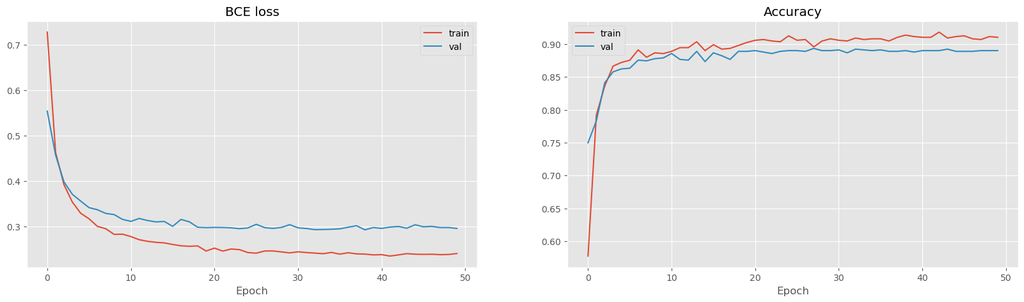

```python
### BEGIN ANSWER
params = [
    make_layer(64, 32, lambda x: x),
    make_layer(32, 1, sigmoid),
]

# train the network
fit(params, split_x, split_y,
    epochs = 50,
    learning_rate = 0.01,
    batch_size = 10)
### END ANSWER
```

**1.6 i Add comment(i) How does the performance of this network compare with the previous networks. Can you explain this result? What is the influence of the activation functions in the network? (1 point)**

Answer: The performance of a network with two linear layers without a ReLU in between is the same as that of a network with a single linear layer. Two linear layers without a nonlinearity in between can be combined into a single linear layer:

The network \begin{align} H_1 &= X W_1 + b_1 \\ H_2 &= H_1 W_2 + b_2 \end{align} can be rewritten as \begin{align} H_2 &= (X W_1 + b_1) W_2 + b_2 \\ &= X W_1 W_2 + (b_1 W_2 + b_2) \\ &= X W_{combined} + b_{combined} \end{align} with \begin{align} W_{combined} &= W_1 W_2 & b_{combined} = b_1 W_2 + b_2 \end{align}

Note that in practice the results can be slightly different, because the a two layer model still has more parameters, and the effective learning rate for $W_{combined}$ is different.

The activation function (such as a ReLU or sigmoid) adds a nonlinear transformation, which means that the two layers can no longer be collapsed into one. This allows the model to learn more complex functions.

*Grading:*

- 1 point for a correct argument that discusses why you need an activation function between two linear layers. Either saying that the result is still linear, or by comparing the performance to a single layer network. (The mathematical derivation is not required.)
- 0.5 point for only observing that the network without non-linearities is worse.

**1.6 j Add comment(j) One way to improve the performance of a neural network is by increasing the number of layers. Try a deeper network (e.g., a network with four layers) to see if this outperforms the previous networks. (1 point)**

*Grading:*

- 1 point for a correct implementation, trained with good hyperparameters.
- No points for a network with linear layers without activation functions in between.

```
Epoch   0: train loss 0.568, acc 0.692;  validation loss 0.424, acc 0.846
Epoch   1: train loss 0.333, acc 0.883;  validation loss 0.295, acc 0.893
Epoch   2: train loss 0.241, acc 0.921;  validation loss 0.242, acc 0.907
Epoch   3: train loss 0.191, acc 0.935;  validation loss 0.220, acc 0.920
Epoch   4: train loss 0.161, acc 0.944;  validation loss 0.189, acc 0.924
Epoch   5: train loss 0.138, acc 0.951;  validation loss 0.180, acc 0.933
Epoch   6: train loss 0.121, acc 0.963;  validation loss 0.165, acc 0.933
Epoch   7: train loss 0.107, acc 0.965;  validation loss 0.145, acc 0.943
Epoch   8: train loss 0.097, acc 0.969;  validation loss 0.141, acc 0.942
Epoch   9: train loss 0.087, acc 0.972;  validation loss 0.129, acc 0.949
Epoch  10: train loss 0.079, acc 0.976;  validation loss 0.124, acc 0.951
Epoch  11: train loss 0.071, acc 0.979;  validation loss 0.120, acc 0.952
Epoch  12: train loss 0.063, acc 0.982;  validation loss 0.114, acc 0.956
Epoch  13: train loss 0.062, acc 0.981;  validation loss 0.109, acc 0.959
Epoch  14: train loss 0.054, acc 0.987;  validation loss 0.108, acc 0.959
Epoch  15: train loss 0.048, acc 0.985;  validation loss 0.114, acc 0.954
Epoch  16: train loss 0.046, acc 0.989;  validation loss 0.102, acc 0.959
Epoch  17: train loss 0.041, acc 0.992;  validation loss 0.101, acc 0.960
Epoch  18: train loss 0.038, acc 0.992;  validation loss 0.117, acc 0.950
Epoch  19: train loss 0.035, acc 0.994;  validation loss 0.097, acc 0.963
Epoch  20: train loss 0.034, acc 0.996;  validation loss 0.092, acc 0.969
Epoch  21: train loss 0.031, acc 0.992;  validation loss 0.092, acc 0.966
Epoch  22: train loss 0.028, acc 0.994;  validation loss 0.089, acc 0.967
Epoch  23: train loss 0.027, acc 0.997;  validation loss 0.089, acc 0.971
Epoch  24: train loss 0.024, acc 0.998;  validation loss 0.087, acc 0.964
Epoch  25: train loss 0.023, acc 0.996;  validation loss 0.095, acc 0.964
Epoch  26: train loss 0.021, acc 0.996;  validation loss 0.089, acc 0.968
Epoch  27: train loss 0.020, acc 0.998;  validation loss 0.087, acc 0.971
Epoch  28: train loss 0.018, acc 0.997;  validation loss 0.086, acc 0.971
Epoch  29: train loss 0.017, acc 0.998;  validation loss 0.087, acc 0.972
Epoch  30: train loss 0.016, acc 0.998;  validation loss 0.084, acc 0.972
Epoch  31: train loss 0.015, acc 0.999;  validation loss 0.085, acc 0.972
Epoch  32: train loss 0.015, acc 0.998;  validation loss 0.087, acc 0.972
Epoch  33: train loss 0.013, acc 0.999;  validation loss 0.082, acc 0.971
Epoch  34: train loss 0.012, acc 0.999;  validation loss 0.084, acc 0.971
Epoch  35: train loss 0.012, acc 0.999;  validation loss 0.087, acc 0.970
Epoch  36: train loss 0.012, acc 0.999;  validation loss 0.085, acc 0.973
Epoch  37: train loss 0.010, acc 0.999;  validation loss 0.080, acc 0.973
Epoch  38: train loss 0.010, acc 0.999;  validation loss 0.084, acc 0.972
Epoch  39: train loss 0.009, acc 0.999;  validation loss 0.082, acc 0.971
Epoch  40: train loss 0.009, acc 0.999;  validation loss 0.083, acc 0.973
Epoch  41: train loss 0.008, acc 1.000;  validation loss 0.081, acc 0.973
Epoch  42: train loss 0.008, acc 1.000;  validation loss 0.085, acc 0.974
Epoch  43: train loss 0.008, acc 1.000;  validation loss 0.082, acc 0.973
Epoch  44: train loss 0.007, acc 1.000;  validation loss 0.082, acc 0.973
Epoch  45: train loss 0.007, acc 1.000;  validation loss 0.081, acc 0.973
Epoch  46: train loss 0.006, acc 1.000;  validation loss 0.082, acc 0.974
Epoch  47: train loss 0.006, acc 1.000;  validation loss 0.084, acc 0.974
Epoch  48: train loss 0.006, acc 1.000;  validation loss 0.082, acc 0.974
Epoch  49: train loss 0.006, acc 1.000;  validation loss 0.082, acc 0.974
After 50 epochs
  train      loss 0.006, accuracy 1.000
  validation loss 0.082, accuracy 0.974
```

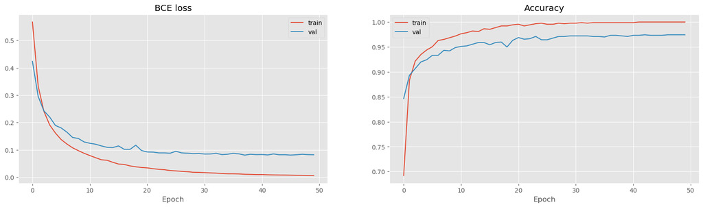

```python
### BEGIN ANSWER
params = [
    make_layer(64, 64, relu),
    make_layer(64, 64, relu),
    make_layer(64, 32, relu),
    make_layer(32, 1, sigmoid),
]

# train the network
fit(params, split_x, split_y,
    epochs = 50,
    learning_rate = 0.01,
    batch_size = 10)
### END ANSWER
```

**1.6 k Add comment(k) Discuss your findings. Were you able to obtain a perfect classification? Explain the learning curves. (1 point)**

Answer: This more complex model performs better than the simpler models. However, it is not possible to get a perfect classification on the test set. The near-perfect accuracy on the training set is due to overfitting.

*Grading:*

- 0.5 point for comparing simple and complex models.
- plus 0.5 point for an answer that mentions the imperfect results on the test set.

## 1.7 Final questions (6 points)

You now have some experience training neural networks. Time for a few final questions.

**1.7 a Add comment(a) What is the influence of the learning rate? What happens if the learning rate is too low or too high? (2 points)**

Answer:

The learning rate determines the size of the gradient descent updates. If the learning rate is too low, the model learns slowly and might get stuck in a local optimum. If the learning rate is too high, the update steps may be too large to optimize the model precisely. The large updates can also introduce numerical problems.

*Grading:*

- 2 points for a correct argument that discusses both low and high learning rates.
- Max. 1 point if only one is discussed.

**1.7 b Add comment(b) What is the role of the minibatch size in SGD? Explain the downsides of a minibatch size that is too small or too high. (2 points)**

Answer:

The minibatch size has an effect on the quality of the gradient estimates.

- If the minibatch is very small, the estimated gradient will not be close to the true gradient, which makes it more difficult to optimize the model.
- On the other hand, a very large minibatch size is inefficient: it provides high-quality gradient estimates, but each update step requires much more computations.
- *(Optional, not required for points.)* For very large models, there may also be a practical limit to the minibatch size, because the available GPU memory is limited.
- *(Optional, not required for points.)* The noise from small minibatches might help the optimizer to escape local minima, and have a regularizing effect.

*Grading:*

- 2 point for a correct argument that discusses both small and large minibatch sizes.
- Max. 1 point if only one is discussed.

**1.7 c Add comment(c) In the linear layer, we initialized the weights $w$ with random values, but we initialized the bias $b$ with zeros. What would happen if the weights $w$ were initialised as zeros? Why is this not a problem for the bias? (2 points)**

Answer:

If all weights $w$ are initialised as zeros, the output of the model would be zero as well. Moreover, it will be impossible for the model to move away from this, since the gradients also depend on $w$: the updates would be zero as well. It is much better to initialise the weights to random values. Another way of looking at this is by noting that if all the weights of two neurons are the same, then their outputs will also always be the same, and so will the gradients. It is impossible to break this symmetry with gradient based optimization. Using (small) random weights can break this symmetry.

For the bias $b$, initialising to zero is not a problem, because they are not used as multiplication terms in the backpropagated gradients. (In fact, biases are usually initialised to 0 in most applications.) Symmetry of the neurons is also not a problem with identical biases, as long as the neurons' weights are different.

*Grading:*

- 1 point for a correct argument about the weights (either about zero outputs or identical neurons),
- 1 point for a correct argument about the bias.
- Either an argument about the output being zero or about symmetry between neurons is okay.

## The end

Well done! Please double check the instructions at the top before you submit your results.

*This assignment has 42 points.* Version 7ac2078 / 2024-09-11

## Score form

Something didn't work. Save the following list of scores in a text file and upload to Brightspace:

Download the scores as a text file